# ЛР_3

Лабораторная работа №3. Выполнил: Телегин Степан Сергеевич, 3ПМИ-ИП3.

Задание. Выполнить предварительную обработку данных на основе имеющегося файла homeEnergyConsumption.csv

1. Загрузить набор данных.

```python
import pandas as pd
import matplotlib.pyplot as plt
import seaborn as sns
import warnings
warnings.filterwarnings('ignore')

df = pd.read_csv('homeEnergyConsumption.csv')
df.head()
```

|  | YearMade | WallType | RoofType | NumOfBedrooms | StovenFuelType | HeatingEquipmentType | HeatingEquipmentAge | NumOfRoomsHeated | FuelUsedForWaterHeating | WaterHeaterSize | AirConditioning | NumOfRoomsCooled | NumOfWindows | TotalSquareHeated | TotalSquareCooled | ElectricityConsumption |
| --- | --- | --- | --- | --- | --- | --- | --- | --- | --- | --- | --- | --- | --- | --- | --- | --- |
| 0 | 2004 | Brick | Composition Shingles | 4 | Electricity | Central Warm-Air Furnace | 5-9 Years old | 9 | Electricity | Large | True | 9 | 41 | 3958 | 3958 | 18466 |
| 1 | 1998 | Wood | Wood Shingles | 3 | Natural Gas | Central Warm-Air Furnace | 10-14 Years old | 4 | Natural Gas | Large | True | 4 | 41 | 2736 | 2736 | 5148 |
| 2 | 1965 | Brick | NaN | 1 | Natural Gas | Steam or Hot Water System | 2-4 Years old | 2 | Natural Gas | Large | True | -1 | 20 | 528 | 264 | 2218 |
| 3 | 1985 | Stone | Composition Shingles | 3 | - | Central Warm-Air Furnace | 5-9 Years old | 7 | Electricity | Large | True | 7 | 41 | 1623 | 1623 | 10015 |
| 4 | 1983 | Wood | Composition Shingles | 2 | Electricity | Central Warm-Air Furnace | <2 Years old | 5 | Natural Gas | Medium | False | -1 | 30 | 1274 | 0 | 2869 |

2. Провести предварительный анализ набора данных (с пом. методов describe и info) .

```python
df.describe()
df.info()
```

```
<class 'pandas.DataFrame'>
RangeIndex: 1001 entries, 0 to 1000
Data columns (total 16 columns):
 #   Column                   Non-Null Count  Dtype
---  ------                   --------------  -----
 0   YearMade                 1001 non-null   int64
 1   WallType                 1001 non-null   str
 2   RoofType                 834 non-null    str
 3   NumOfBedrooms            1001 non-null   int64
 4   StovenFuelType           1001 non-null   str
 5   HeatingEquipmentType     962 non-null    str
 6   HeatingEquipmentAge      1001 non-null   str
 7   NumOfRoomsHeated         1001 non-null   int64
 8   FuelUsedForWaterHeating  1001 non-null   str
 9   WaterHeaterSize          961 non-null    str
 10  AirConditioning          1001 non-null   bool
 11  NumOfRoomsCooled         1001 non-null   int64
 12  NumOfWindows             1001 non-null   int64
 13  TotalSquareHeated        1001 non-null   int64
 14  TotalSquareCooled        1001 non-null   int64
 15  ElectricityConsumption   1001 non-null   int64
dtypes: bool(1), int64(8), str(7)
memory usage: 118.4 KB
```

3. Получить список категориальных и числовых признаков.

```python
from pandas.api.types import is_numeric_dtype

listOfCategoricalFeatures = []
listOfNumericalFeatures = []

for column in df.columns:
    if not is_numeric_dtype(df[column]):
        listOfCategoricalFeatures.append(column)
    else:
        listOfNumericalFeatures.append(column)

# AirConditioning это bool, убираем его из числовых
listOfNumericalFeatures.remove('AirConditioning')

print('Категориальные признаки:', listOfCategoricalFeatures)
print('Числовые признаки:', listOfNumericalFeatures)
```

```
Категориальные признаки: ['WallType', 'RoofType', 'StovenFuelType', 'HeatingEquipmentType', 'HeatingEquipmentAge', 'FuelUsedForWaterHeating', 'WaterHeaterSize']
Числовые признаки: ['YearMade', 'NumOfBedrooms', 'NumOfRoomsHeated', 'NumOfRoomsCooled', 'NumOfWindows', 'TotalSquareHeated', 'TotalSquareCooled', 'ElectricityConsumption']
```

4. Вывести количество объектов в наборе для всех категорий. Вывести Уникальные значения в категориальных столбцах. Выполнить визуализацию распределений числовых переменных (Парные графики для числовых признаков).

```
Признак: WallType
Количество значений:
WallType
Siding         324
Brick          258
Wood           182
Stucco         160
Concrete        46
Composition     15
Stone           12
Other            4
Name: count, dtype: int64
Уникальные значения: <StringArray>
[      'Brick',        'Wood',       'Stone',      'Stucco',      'Siding',
    'Concrete', 'Composition',       'Other']
Length: 8, dtype: str

Признак: RoofType
Количество значений:
RoofType
Composition Shingles     491
Asphalt                  172
Wood Shingles             57
Metal                     48
Ceramic or Clay Tiles     36
Concrete Tiles            17
Other                      7
Slate                      6
Name: count, dtype: int64
Уникальные значения: <StringArray>
[ 'Composition Shingles',         'Wood Shingles',                     nan,
               'Asphalt', 'Ceramic or Clay Tiles',                 'Other',
                 'Metal',        'Concrete Tiles',                 'Slate']
Length: 9, dtype: str

Признак: StovenFuelType
Количество значений:
StovenFuelType
Electricity    559
Natural Gas    320
```

[output cut: 60 more lines]

```
Уникальные значения: <StringArray>
[   'Electricity',    'Natural Gas', 'Not Applicable',       'Fuel Oil',
          'Solar',     'Other Fuel',           'Wood',    'Propane/LPG']
Length: 8, dtype: str

Признак: WaterHeaterSize
Количество значений:
WaterHeaterSize
Medium    502
Large     322
Small     137
Name: count, dtype: int64
Уникальные значения: <StringArray>
['Large', 'Medium', 'Small', nan]
Length: 4, dtype: str
```

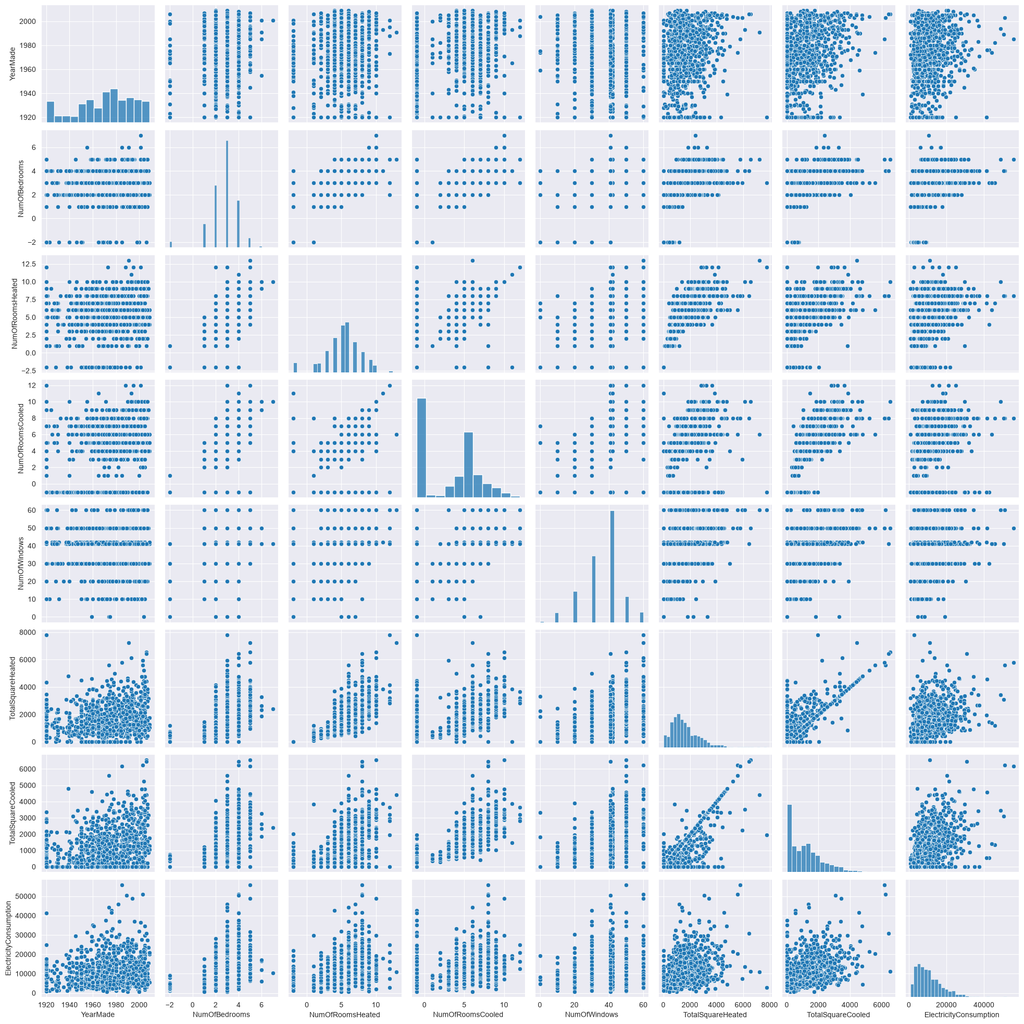

```python
for column in listOfCategoricalFeatures:
    print(f'Признак: {column}')
    print('Количество значений:')
    print(df[column].value_counts())
    print('Уникальные значения:', df[column].unique())
    print()

# парные графики для числовых признаков
sns.pairplot(df[listOfNumericalFeatures])
plt.show()
```

5. (1) Удалить строки из набора, где для каждого числового признака его значения меньше процентиля 2.5 и больше процентиля 97.5.

```python
for column in listOfNumericalFeatures:
    minLimit = df[column].quantile(0.025)
    maxLimit = df[column].quantile(0.975)
    df = df.loc[(df[column] >= minLimit) & (df[column] <= maxLimit)]

print(df.shape)
```

```
(837, 16)
```

5. (2) Заменить все отсутствующие значения для признака WaterHeaterSize (размер водонагревателя) значением моды.

```python
modeWaterHeaterSize = df['WaterHeaterSize'].mode()[0]

# None это тоже по сути пропуск, меняем на моду
df['WaterHeaterSize'] = df['WaterHeaterSize'].replace('None', modeWaterHeaterSize)
df['WaterHeaterSize'] = df['WaterHeaterSize'].fillna(modeWaterHeaterSize)

# размер порядковый, переводим в числа
waterHeaterSizeDict = {'Small': 1, 'Medium': 2, 'Large': 3}
df['WaterHeaterSize'] = df['WaterHeaterSize'].map(waterHeaterSizeDict)
```

6. Устранить отрицательные значения в столбце NumOfRoomsCooled (количество комнат с кондиционированием).

```python
# -1 здесь означает что кондиционера нет, так что просто ставим 0
df.loc[df['NumOfRoomsCooled'] < 0, 'NumOfRoomsCooled'] = 0
```

7. Удалить строки, в которых не содержится значения по типу системы отопления (HeatingEquipmentType)

```python
df = df.dropna(subset=['HeatingEquipmentType'])
```

8. Для атрибутов RoofType (тип крыши), StovenFuelType (тип топлива для печи) в случае их отсутствия поставить значение Unknown.

```python
df['RoofType'] = df['RoofType'].fillna('Unknown')

# здесь вместо пропуска стоит прочерк, тоже меняем
df['StovenFuelType'] = df['StovenFuelType'].replace('-', 'Unknown')
df['StovenFuelType'] = df['StovenFuelType'].fillna('Unknown')
```

9. Закодировать значения HeatingEquipmentAge (возраст системы отопления)

```python
mainHeatingEquipmentAgeDict = {
    '<2 Years old': 1, '2-4 Years old': 2, '5-9 Years old': 3,
    '10-14 Years old': 4, '15-19 Years old': 5, '>20 Years old': 6
}
df['HeatingEquipmentAge'] = df['HeatingEquipmentAge'].map(mainHeatingEquipmentAgeDict)

# если осталось Not Applicable, то после map оно стало NaN, эти строки нам не нужны
df = df.dropna(subset=['HeatingEquipmentAge'])
```

10. Удалить из набора объекты с редкими категориями (чей процент встречаемости для оставшихся строк меньше 3)

```python
for column in listOfCategoricalFeatures:
    print(f'Признак: {column}')
    print(df[column].value_counts())

for column in listOfCategoricalFeatures:
    threshold = df.shape[0] * 0.03 # 3% от числа оставшихся строк
    counts = df[column].value_counts()
    listOfIndices = counts.index[counts > threshold].tolist()
    df = df.loc[df[column].isin(listOfIndices)]

print('Итоговый размер:', df.shape)
```

```
Признак: WallType
WallType
Siding         273
Brick          208
Wood           150
Stucco         115
Concrete        32
Composition     13
Stone           10
Other            4
Name: count, dtype: int64
Признак: RoofType
RoofType
Composition Shingles     393
Asphalt                  148
Unknown                  130
Wood Shingles             49
Metal                     42
Ceramic or Clay Tiles     20
Concrete Tiles            12
Other                      6
Slate                      5
Name: count, dtype: int64
Признак: StovenFuelType
StovenFuelType
Electricity    456
Natural Gas    269
Unknown         59
Propane/LPG     19
Other Fuel       2
Name: count, dtype: int64
Признак: HeatingEquipmentType
HeatingEquipmentType
Central Warm-Air Furnace          525
Steam or Hot Water System          96
Heat Pump                          58
Built-In Electric Units            45
Built-In Room Heater               25
Floor or Wall Pipeless Furnace     18
Portable Electric Heaters          15
```

[output cut: 17 more lines]

```
Electricity       316
Fuel Oil           39
Propane/LPG        14
Solar               2
Other Fuel          2
Wood                1
Not Applicable      1
Name: count, dtype: int64
Признак: WaterHeaterSize
WaterHeaterSize
2    456
3    232
1    117
Name: count, dtype: int64
Итоговый размер: (640, 16)
```

11. Сохранить полученный набор в файл

```python
# смотрим, сколько пропусков осталось в каждой колонке
df.isna().sum()

print('Финальный размер:', df.shape)
df.to_csv('homeEnergyConsumption_cleaned.csv', index=False)
```

```
Финальный размер: (640, 16)
```

Заключение

В ходе работы была выполнена предварительная обработка набора данных homeEnergyConsumption.csv, содержащего 1001 запись и 16 признаков о жилых домах и их электропотреблении. Данные загружены, проанализированы методами describe() и info(), признаки разделены на категориальные и числовые.

Проведена очистка: удалены выбросы по границам 2.5 и 97.5 процентилей (набор сократился с 1001 до 837 записей); пропуски в WaterHeaterSize заменены модой и признак закодирован числами; отрицательные значения NumOfRoomsCooled заменены на 0; удалены строки без HeatingEquipmentType; пропуски в RoofType и StovenFuelType заменены на 'Unknown'; HeatingEquipmentAge закодирован числами 1–6; удалены редкие категории с встречаемостью меньше 3%.

Итоговый набор содержит 640 записей и 16 признаков, пропусков нет. Результат сохранён в новый файл homeEnergyConsumption_cleaned.csv.